# Risk Factor Analysis

## Outcome Variable

**Outcome Variable:** swasted

## Predictor Variables

**Intervention Variable:** birthlen

**Adjustment Set:**

- arm
- sex
- W_mage
- meducyrs
- feducyrs
- hhwealth_quart
- vagbrth
- W_nrooms
- brthmon
- W_parity
- impfloor
- impsan
- safeh20
- delta_W_mage
- delta_meducyrs
- delta_feducyrs
- delta_hhwealth_quart
- delta_vagbrth
- delta_W_nrooms
- delta_brthmon
- delta_W_parity
- delta_impfloor
- delta_impsan
- delta_safeh20

## Stratifying Variables

The analysis was stratified on these variable(s):

- agecat
- studyid
- country

## Data Summary

| agecat | studyid | country | birthlen | swasted | n_cell | n |
| --- | --- | --- | --- | --- | --- | --- |
| Birth | ki0047075b-MAL-ED | BANGLADESH | >=50 cm | 0 | 25 | 241 |
| Birth | ki0047075b-MAL-ED | BANGLADESH | >=50 cm | 1 | 4 | 241 |
| Birth | ki0047075b-MAL-ED | BANGLADESH | <48 cm | 0 | 126 | 241 |
| Birth | ki0047075b-MAL-ED | BANGLADESH | <48 cm | 1 | 2 | 241 |
| Birth | ki0047075b-MAL-ED | BANGLADESH | [48-50) cm | 0 | 82 | 241 |
| Birth | ki0047075b-MAL-ED | BANGLADESH | [48-50) cm | 1 | 2 | 241 |
| Birth | ki0047075b-MAL-ED | BRAZIL | >=50 cm | 0 | 34 | 183 |
| Birth | ki0047075b-MAL-ED | BRAZIL | >=50 cm | 1 | 0 | 183 |
| Birth | ki0047075b-MAL-ED | BRAZIL | <48 cm | 0 | 73 | 183 |
| Birth | ki0047075b-MAL-ED | BRAZIL | <48 cm | 1 | 0 | 183 |
| Birth | ki0047075b-MAL-ED | BRAZIL | [48-50) cm | 0 | 76 | 183 |
| Birth | ki0047075b-MAL-ED | BRAZIL | [48-50) cm | 1 | 0 | 183 |
| Birth | ki0047075b-MAL-ED | INDIA | >=50 cm | 0 | 25 | 203 |
| Birth | ki0047075b-MAL-ED | INDIA | >=50 cm | 1 | 0 | 203 |
| Birth | ki0047075b-MAL-ED | INDIA | <48 cm | 0 | 98 | 203 |
| Birth | ki0047075b-MAL-ED | INDIA | <48 cm | 1 | 6 | 203 |
| Birth | ki0047075b-MAL-ED | INDIA | [48-50) cm | 0 | 73 | 203 |
| Birth | ki0047075b-MAL-ED | INDIA | [48-50) cm | 1 | 1 | 203 |
| Birth | ki0047075b-MAL-ED | NEPAL | >=50 cm | 0 | 36 | 168 |
| Birth | ki0047075b-MAL-ED | NEPAL | >=50 cm | 1 | 2 | 168 |
| Birth | ki0047075b-MAL-ED | NEPAL | <48 cm | 0 | 62 | 168 |
| Birth | ki0047075b-MAL-ED | NEPAL | <48 cm | 1 | 2 | 168 |
| Birth | ki0047075b-MAL-ED | NEPAL | [48-50) cm | 0 | 66 | 168 |
| Birth | ki0047075b-MAL-ED | NEPAL | [48-50) cm | 1 | 0 | 168 |
| Birth | ki0047075b-MAL-ED | PERU | >=50 cm | 0 | 34 | 279 |
| Birth | ki0047075b-MAL-ED | PERU | >=50 cm | 1 | 0 | 279 |
| Birth | ki0047075b-MAL-ED | PERU | <48 cm | 0 | 134 | 279 |
| Birth | ki0047075b-MAL-ED | PERU | <48 cm | 1 | 0 | 279 |
| Birth | ki0047075b-MAL-ED | PERU | [48-50) cm | 0 | 111 | 279 |
| Birth | ki0047075b-MAL-ED | PERU | [48-50) cm | 1 | 0 | 279 |

[output cut: 432 more lines]

The following strata were considered:

- agecat: 24 months, studyid: ki0047075b-MAL-ED, country: BANGLADESH
- agecat: 24 months, studyid: ki0047075b-MAL-ED, country: BRAZIL
- agecat: 24 months, studyid: ki0047075b-MAL-ED, country: INDIA
- agecat: 24 months, studyid: ki0047075b-MAL-ED, country: NEPAL
- agecat: 24 months, studyid: ki0047075b-MAL-ED, country: PERU
- agecat: 24 months, studyid: ki0047075b-MAL-ED, country: SOUTH AFRICA
- agecat: 24 months, studyid: ki0047075b-MAL-ED, country: TANZANIA, UNITED REPUBLIC OF
- agecat: 24 months, studyid: ki1000108-CMC-V-BCS-2002, country: INDIA
- agecat: 24 months, studyid: ki1000108-IRC, country: INDIA
- agecat: 24 months, studyid: ki1017093-NIH-Birth, country: BANGLADESH
- agecat: 24 months, studyid: ki1017093b-PROVIDE, country: BANGLADESH
- agecat: 24 months, studyid: ki1017093c-NIH-Crypto, country: BANGLADESH
- agecat: 24 months, studyid: ki1101329-Keneba, country: GAMBIA
- agecat: 24 months, studyid: ki1114097-CMIN, country: BANGLADESH
- agecat: 24 months, studyid: ki1114097-CMIN, country: PERU
- agecat: 24 months, studyid: ki1114097-CONTENT, country: PERU
- agecat: 24 months, studyid: ki1119695-PROBIT, country: BELARUS
- agecat: 24 months, studyid: ki1126311-ZVITAMBO, country: ZIMBABWE
- agecat: 24 months, studyid: ki1135781-COHORTS, country: GUATEMALA
- agecat: 24 months, studyid: ki1135781-COHORTS, country: INDIA
- agecat: 24 months, studyid: ki1135781-COHORTS, country: PHILIPPINES
- agecat: 24 months, studyid: kiGH5241-JiVitA-3, country: BANGLADESH
- agecat: 24 months, studyid: kiGH5241-JiVitA-4, country: BANGLADESH
- agecat: 6 months, studyid: ki0047075b-MAL-ED, country: BANGLADESH
- agecat: 6 months, studyid: ki0047075b-MAL-ED, country: BRAZIL
- agecat: 6 months, studyid: ki0047075b-MAL-ED, country: INDIA
- agecat: 6 months, studyid: ki0047075b-MAL-ED, country: NEPAL
- agecat: 6 months, studyid: ki0047075b-MAL-ED, country: PERU
- agecat: 6 months, studyid: ki0047075b-MAL-ED, country: SOUTH AFRICA
- agecat: 6 months, studyid: ki0047075b-MAL-ED, country: TANZANIA, UNITED REPUBLIC OF
- agecat: 6 months, studyid: ki1000108-CMC-V-BCS-2002, country: INDIA
- agecat: 6 months, studyid: ki1000108-IRC, country: INDIA
- agecat: 6 months, studyid: ki1000109-EE, country: PAKISTAN
- agecat: 6 months, studyid: ki1000109-ResPak, country: PAKISTAN
- agecat: 6 months, studyid: ki1000304b-SAS-CompFeed, country: INDIA
- agecat: 6 months, studyid: ki1017093-NIH-Birth, country: BANGLADESH
- agecat: 6 months, studyid: ki1017093b-PROVIDE, country: BANGLADESH
- agecat: 6 months, studyid: ki1017093c-NIH-Crypto, country: BANGLADESH
- agecat: 6 months, studyid: ki1101329-Keneba, country: GAMBIA
- agecat: 6 months, studyid: ki1114097-CMIN, country: BANGLADESH
- agecat: 6 months, studyid: ki1114097-CMIN, country: BRAZIL
- agecat: 6 months, studyid: ki1114097-CMIN, country: GUINEA-BISSAU
- agecat: 6 months, studyid: ki1114097-CMIN, country: PERU
- agecat: 6 months, studyid: ki1114097-CONTENT, country: PERU
- agecat: 6 months, studyid: ki1119695-PROBIT, country: BELARUS
- agecat: 6 months, studyid: ki1126311-ZVITAMBO, country: ZIMBABWE
- agecat: 6 months, studyid: ki1135781-COHORTS, country: GUATEMALA
- agecat: 6 months, studyid: ki1135781-COHORTS, country: INDIA
- agecat: 6 months, studyid: ki1135781-COHORTS, country: PHILIPPINES
- agecat: 6 months, studyid: kiGH5241-JiVitA-3, country: BANGLADESH
- agecat: 6 months, studyid: kiGH5241-JiVitA-4, country: BANGLADESH
- agecat: Birth, studyid: ki0047075b-MAL-ED, country: BANGLADESH
- agecat: Birth, studyid: ki0047075b-MAL-ED, country: BRAZIL
- agecat: Birth, studyid: ki0047075b-MAL-ED, country: INDIA
- agecat: Birth, studyid: ki0047075b-MAL-ED, country: NEPAL
- agecat: Birth, studyid: ki0047075b-MAL-ED, country: PERU
- agecat: Birth, studyid: ki0047075b-MAL-ED, country: SOUTH AFRICA
- agecat: Birth, studyid: ki0047075b-MAL-ED, country: TANZANIA, UNITED REPUBLIC OF
- agecat: Birth, studyid: ki1000108-CMC-V-BCS-2002, country: INDIA
- agecat: Birth, studyid: ki1000108-IRC, country: INDIA
- agecat: Birth, studyid: ki1000109-EE, country: PAKISTAN
- agecat: Birth, studyid: ki1000109-ResPak, country: PAKISTAN
- agecat: Birth, studyid: ki1000304b-SAS-CompFeed, country: INDIA
- agecat: Birth, studyid: ki1017093-NIH-Birth, country: BANGLADESH
- agecat: Birth, studyid: ki1017093c-NIH-Crypto, country: BANGLADESH
- agecat: Birth, studyid: ki1101329-Keneba, country: GAMBIA
- agecat: Birth, studyid: ki1114097-CMIN, country: BANGLADESH
- agecat: Birth, studyid: ki1114097-CMIN, country: BRAZIL
- agecat: Birth, studyid: ki1114097-CMIN, country: PERU
- agecat: Birth, studyid: ki1114097-CONTENT, country: PERU
- agecat: Birth, studyid: ki1119695-PROBIT, country: BELARUS
- agecat: Birth, studyid: ki1126311-ZVITAMBO, country: ZIMBABWE
- agecat: Birth, studyid: ki1135781-COHORTS, country: GUATEMALA
- agecat: Birth, studyid: ki1135781-COHORTS, country: INDIA
- agecat: Birth, studyid: ki1135781-COHORTS, country: PHILIPPINES
- agecat: Birth, studyid: kiGH5241-JiVitA-3, country: BANGLADESH
- agecat: Birth, studyid: kiGH5241-JiVitA-4, country: BANGLADESH

### Dropped Strata

Some strata were dropped due to rare outcomes:

- agecat: Birth, studyid: ki0047075b-MAL-ED, country: BANGLADESH
- agecat: Birth, studyid: ki0047075b-MAL-ED, country: BRAZIL
- agecat: Birth, studyid: ki0047075b-MAL-ED, country: INDIA
- agecat: Birth, studyid: ki0047075b-MAL-ED, country: NEPAL
- agecat: Birth, studyid: ki0047075b-MAL-ED, country: PERU
- agecat: Birth, studyid: ki0047075b-MAL-ED, country: SOUTH AFRICA
- agecat: Birth, studyid: ki0047075b-MAL-ED, country: TANZANIA, UNITED REPUBLIC OF
- agecat: Birth, studyid: ki1000108-CMC-V-BCS-2002, country: INDIA
- agecat: Birth, studyid: ki1000109-EE, country: PAKISTAN
- agecat: Birth, studyid: ki1000109-ResPak, country: PAKISTAN
- agecat: Birth, studyid: ki1000304b-SAS-CompFeed, country: INDIA
- agecat: Birth, studyid: ki1017093-NIH-Birth, country: BANGLADESH
- agecat: Birth, studyid: ki1017093c-NIH-Crypto, country: BANGLADESH
- agecat: Birth, studyid: ki1101329-Keneba, country: GAMBIA
- agecat: Birth, studyid: ki1114097-CMIN, country: BANGLADESH
- agecat: Birth, studyid: ki1114097-CMIN, country: BRAZIL
- agecat: Birth, studyid: ki1114097-CMIN, country: PERU
- agecat: Birth, studyid: ki1114097-CONTENT, country: PERU
- agecat: Birth, studyid: ki1119695-PROBIT, country: BELARUS
- agecat: Birth, studyid: ki1135781-COHORTS, country: GUATEMALA
- agecat: Birth, studyid: kiGH5241-JiVitA-4, country: BANGLADESH
- agecat: 6 months, studyid: ki0047075b-MAL-ED, country: BANGLADESH
- agecat: 6 months, studyid: ki0047075b-MAL-ED, country: BRAZIL
- agecat: 6 months, studyid: ki0047075b-MAL-ED, country: INDIA
- agecat: 6 months, studyid: ki0047075b-MAL-ED, country: NEPAL
- agecat: 6 months, studyid: ki0047075b-MAL-ED, country: PERU
- agecat: 6 months, studyid: ki0047075b-MAL-ED, country: SOUTH AFRICA
- agecat: 6 months, studyid: ki0047075b-MAL-ED, country: TANZANIA, UNITED REPUBLIC OF
- agecat: 6 months, studyid: ki1000108-CMC-V-BCS-2002, country: INDIA
- agecat: 6 months, studyid: ki1000108-IRC, country: INDIA
- agecat: 6 months, studyid: ki1000109-EE, country: PAKISTAN
- agecat: 6 months, studyid: ki1000109-ResPak, country: PAKISTAN
- agecat: 6 months, studyid: ki1000304b-SAS-CompFeed, country: INDIA
- agecat: 6 months, studyid: ki1017093-NIH-Birth, country: BANGLADESH
- agecat: 6 months, studyid: ki1017093b-PROVIDE, country: BANGLADESH
- agecat: 6 months, studyid: ki1017093c-NIH-Crypto, country: BANGLADESH
- agecat: 6 months, studyid: ki1101329-Keneba, country: GAMBIA
- agecat: 6 months, studyid: ki1114097-CMIN, country: BANGLADESH
- agecat: 6 months, studyid: ki1114097-CMIN, country: BRAZIL
- agecat: 6 months, studyid: ki1114097-CMIN, country: GUINEA-BISSAU
- agecat: 6 months, studyid: ki1114097-CMIN, country: PERU
- agecat: 6 months, studyid: ki1114097-CONTENT, country: PERU
- agecat: 6 months, studyid: ki1119695-PROBIT, country: BELARUS
- agecat: 6 months, studyid: ki1135781-COHORTS, country: GUATEMALA
- agecat: 24 months, studyid: ki0047075b-MAL-ED, country: BANGLADESH
- agecat: 24 months, studyid: ki0047075b-MAL-ED, country: BRAZIL
- agecat: 24 months, studyid: ki0047075b-MAL-ED, country: INDIA
- agecat: 24 months, studyid: ki0047075b-MAL-ED, country: NEPAL
- agecat: 24 months, studyid: ki0047075b-MAL-ED, country: PERU
- agecat: 24 months, studyid: ki0047075b-MAL-ED, country: SOUTH AFRICA
- agecat: 24 months, studyid: ki0047075b-MAL-ED, country: TANZANIA, UNITED REPUBLIC OF
- agecat: 24 months, studyid: ki1000108-CMC-V-BCS-2002, country: INDIA
- agecat: 24 months, studyid: ki1000108-IRC, country: INDIA
- agecat: 24 months, studyid: ki1017093-NIH-Birth, country: BANGLADESH
- agecat: 24 months, studyid: ki1017093b-PROVIDE, country: BANGLADESH
- agecat: 24 months, studyid: ki1017093c-NIH-Crypto, country: BANGLADESH
- agecat: 24 months, studyid: ki1114097-CMIN, country: BANGLADESH
- agecat: 24 months, studyid: ki1114097-CMIN, country: PERU
- agecat: 24 months, studyid: ki1114097-CONTENT, country: PERU
- agecat: 24 months, studyid: ki1119695-PROBIT, country: BELARUS
- agecat: 24 months, studyid: ki1126311-ZVITAMBO, country: ZIMBABWE
- agecat: 24 months, studyid: ki1135781-COHORTS, country: GUATEMALA
- agecat: 24 months, studyid: ki1135781-COHORTS, country: PHILIPPINES

## Methods Detail

We’re interested in the causal parameters $E[Y_a]$ for all values of $a \in \mathcal{A}$. These parameters represent the mean outcome if, possibly contrary to fact, we intervened to set all units to have $A=a$. Under the randomization and positivity assumptions, these are identified by the statistical parameters $\psi_a=E_W[E_{Y|A,W}(Y|A=a,W)]$. In addition, we’re interested in the mean of $Y$, $E[Y]$ under no intervention (the observed mean). We will estimate these parameters by using SuperLearner to fit the relevant likelihood factors – $E_{Y|A,W}(Y|A=a,W)$ and $p(A=a|W)$, and then updating our likelihood fit using a joint TMLE.

For unadjusted analyses ($W=\{\}$), initial likelihoods were estimated using Lrnr_glm to estimate the simple $E(Y|A)$ and Lrnr_mean to estimate $p(A)$. For adjusted analyses, a small library containing Lrnr_glmnet, Lrnr_xgboost, and Lrnr_mean was used.

Having estimated these parameters, we will then use the delta method to estimate relative risks and attributable risks relative to a prespecified baseline level of $A$.

# Results Detail

## Results Plots

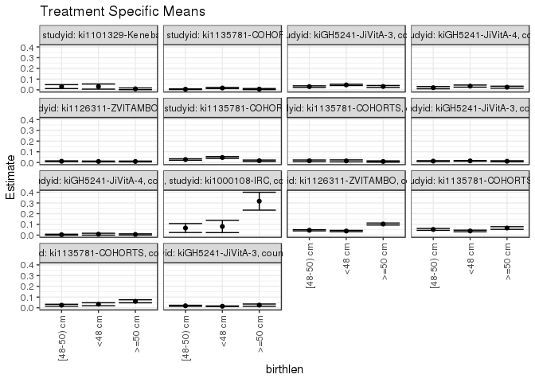

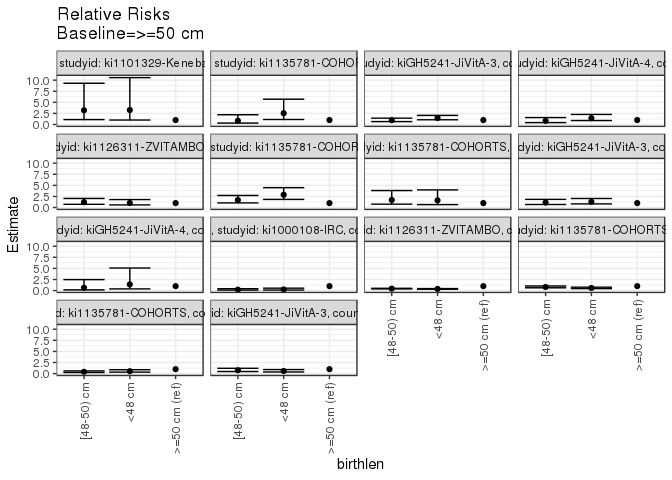

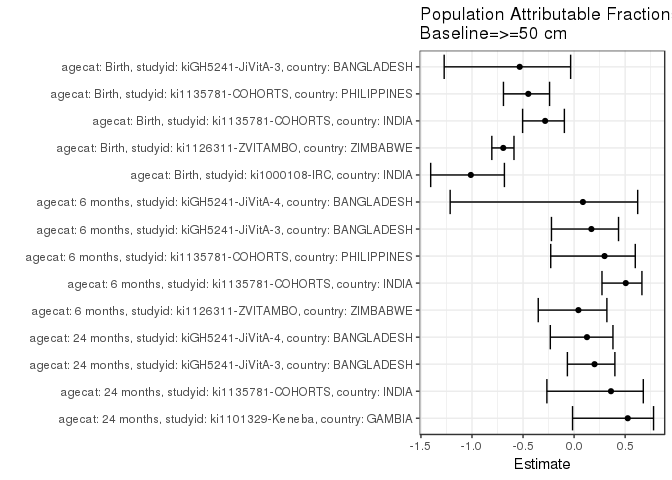

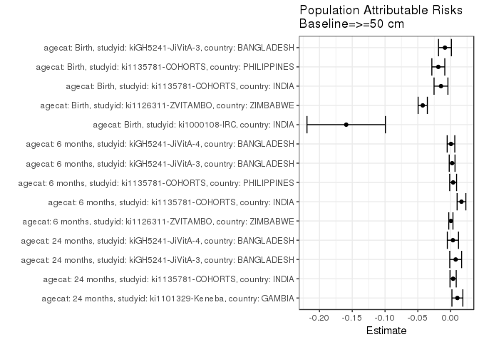

## Results Table

### Parameter: TSM

| agecat | studyid | country | intervention_level | baseline_level | estimate | ci_lower | ci_upper |
| --- | --- | --- | --- | --- | --- | --- | --- |
| Birth | ki1000108-IRC | INDIA | >=50 cm | NA | 0.3166667 | 0.2333160 | 0.4000173 |
| Birth | ki1000108-IRC | INDIA | <48 cm | NA | 0.0804598 | 0.0232201 | 0.1376995 |
| Birth | ki1000108-IRC | INDIA | [48-50) cm | NA | 0.0661765 | 0.0243360 | 0.1080170 |
| Birth | ki1126311-ZVITAMBO | ZIMBABWE | >=50 cm | NA | 0.1037275 | 0.0944345 | 0.1130206 |
| Birth | ki1126311-ZVITAMBO | ZIMBABWE | <48 cm | NA | 0.0382052 | 0.0320695 | 0.0443410 |
| Birth | ki1126311-ZVITAMBO | ZIMBABWE | [48-50) cm | NA | 0.0451153 | 0.0395446 | 0.0506860 |
| Birth | ki1135781-COHORTS | INDIA | >=50 cm | NA | 0.0663215 | 0.0539160 | 0.0787270 |
| Birth | ki1135781-COHORTS | INDIA | <48 cm | NA | 0.0387465 | 0.0311659 | 0.0463270 |
| Birth | ki1135781-COHORTS | INDIA | [48-50) cm | NA | 0.0532311 | 0.0444675 | 0.0619946 |
| Birth | ki1135781-COHORTS | PHILIPPINES | >=50 cm | NA | 0.0604607 | 0.0464886 | 0.0744329 |
| Birth | ki1135781-COHORTS | PHILIPPINES | <48 cm | NA | 0.0329679 | 0.0191125 | 0.0468232 |
| Birth | ki1135781-COHORTS | PHILIPPINES | [48-50) cm | NA | 0.0240492 | 0.0151352 | 0.0329633 |
| Birth | kiGH5241-JiVitA-3 | BANGLADESH | >=50 cm | NA | 0.0247834 | 0.0144168 | 0.0351499 |
| Birth | kiGH5241-JiVitA-3 | BANGLADESH | <48 cm | NA | 0.0144623 | 0.0120196 | 0.0169050 |
| Birth | kiGH5241-JiVitA-3 | BANGLADESH | [48-50) cm | NA | 0.0185396 | 0.0136563 | 0.0234228 |
| 6 months | ki1126311-ZVITAMBO | ZIMBABWE | >=50 cm | NA | 0.0092542 | 0.0055395 | 0.0129688 |
| 6 months | ki1126311-ZVITAMBO | ZIMBABWE | <48 cm | NA | 0.0095408 | 0.0059123 | 0.0131692 |
| 6 months | ki1126311-ZVITAMBO | ZIMBABWE | [48-50) cm | NA | 0.0113255 | 0.0077192 | 0.0149318 |
| 6 months | ki1135781-COHORTS | INDIA | >=50 cm | NA | 0.0162014 | 0.0095664 | 0.0228364 |
| 6 months | ki1135781-COHORTS | INDIA | <48 cm | NA | 0.0464578 | 0.0382887 | 0.0546268 |
| 6 months | ki1135781-COHORTS | INDIA | [48-50) cm | NA | 0.0273332 | 0.0206260 | 0.0340404 |
| 6 months | ki1135781-COHORTS | PHILIPPINES | >=50 cm | NA | 0.0091001 | 0.0031808 | 0.0150194 |
| 6 months | ki1135781-COHORTS | PHILIPPINES | <48 cm | NA | 0.0147710 | 0.0056822 | 0.0238599 |
| 6 months | ki1135781-COHORTS | PHILIPPINES | [48-50) cm | NA | 0.0154889 | 0.0079571 | 0.0230207 |
| 6 months | kiGH5241-JiVitA-3 | BANGLADESH | >=50 cm | NA | 0.0113909 | 0.0066436 | 0.0161382 |
| 6 months | kiGH5241-JiVitA-3 | BANGLADESH | <48 cm | NA | 0.0146870 | 0.0119362 | 0.0174378 |
| 6 months | kiGH5241-JiVitA-3 | BANGLADESH | [48-50) cm | NA | 0.0128114 | 0.0089840 | 0.0166388 |
| 6 months | kiGH5241-JiVitA-4 | BANGLADESH | >=50 cm | NA | 0.0063579 | 0.0010178 | 0.0116979 |
| 6 months | kiGH5241-JiVitA-4 | BANGLADESH | <48 cm | NA | 0.0088220 | 0.0001687 | 0.0174753 |
| 6 months | kiGH5241-JiVitA-4 | BANGLADESH | [48-50) cm | NA | 0.0040161 | -0.0002890 | 0.0083211 |
| 24 months | ki1101329-Keneba | GAMBIA | >=50 cm | NA | 0.0093458 | 0.0011885 | 0.0175031 |
| 24 months | ki1101329-Keneba | GAMBIA | <48 cm | NA | 0.0304569 | 0.0064495 | 0.0544642 |
| 24 months | ki1101329-Keneba | GAMBIA | [48-50) cm | NA | 0.0299401 | 0.0116547 | 0.0482255 |
| 24 months | ki1135781-COHORTS | INDIA | >=50 cm | NA | 0.0067633 | 0.0017695 | 0.0117571 |
| 24 months | ki1135781-COHORTS | INDIA | <48 cm | NA | 0.0171162 | 0.0113260 | 0.0229064 |
| 24 months | ki1135781-COHORTS | INDIA | [48-50) cm | NA | 0.0056850 | 0.0021711 | 0.0091990 |
| 24 months | kiGH5241-JiVitA-3 | BANGLADESH | >=50 cm | NA | 0.0309880 | 0.0218546 | 0.0401213 |
| 24 months | kiGH5241-JiVitA-3 | BANGLADESH | <48 cm | NA | 0.0458603 | 0.0398430 | 0.0518777 |
| 24 months | kiGH5241-JiVitA-3 | BANGLADESH | [48-50) cm | NA | 0.0299397 | 0.0224920 | 0.0373875 |
| 24 months | kiGH5241-JiVitA-4 | BANGLADESH | >=50 cm | NA | 0.0244074 | 0.0150600 | 0.0337547 |
| 24 months | kiGH5241-JiVitA-4 | BANGLADESH | <48 cm | NA | 0.0347615 | 0.0250574 | 0.0444656 |
| 24 months | kiGH5241-JiVitA-4 | BANGLADESH | [48-50) cm | NA | 0.0199153 | 0.0096176 | 0.0302129 |

### Parameter: E(Y)

| agecat | studyid | country | intervention_level | baseline_level | estimate | ci_lower | ci_upper |
| --- | --- | --- | --- | --- | --- | --- | --- |
| Birth | ki1000108-IRC | INDIA | NA | NA | 0.1574344 | 0.1188345 | 0.1960344 |
| Birth | ki1126311-ZVITAMBO | ZIMBABWE | NA | NA | 0.0612419 | 0.0571066 | 0.0653771 |
| Birth | ki1135781-COHORTS | INDIA | NA | NA | 0.0516712 | 0.0461576 | 0.0571849 |
| Birth | ki1135781-COHORTS | PHILIPPINES | NA | NA | 0.0417385 | 0.0344572 | 0.0490198 |
| Birth | kiGH5241-JiVitA-3 | BANGLADESH | NA | NA | 0.0161691 | 0.0138058 | 0.0185324 |
| 6 months | ki1126311-ZVITAMBO | ZIMBABWE | NA | NA | 0.0096636 | 0.0075428 | 0.0117844 |
| 6 months | ki1135781-COHORTS | INDIA | NA | NA | 0.0328056 | 0.0283450 | 0.0372662 |
| 6 months | ki1135781-COHORTS | PHILIPPINES | NA | NA | 0.0129678 | 0.0086988 | 0.0172368 |
| 6 months | kiGH5241-JiVitA-3 | BANGLADESH | NA | NA | 0.0137140 | 0.0115860 | 0.0158421 |
| 6 months | kiGH5241-JiVitA-4 | BANGLADESH | NA | NA | 0.0069583 | 0.0024545 | 0.0114620 |
| 24 months | ki1101329-Keneba | GAMBIA | NA | NA | 0.0196998 | 0.0113537 | 0.0280459 |
| 24 months | ki1135781-COHORTS | INDIA | NA | NA | 0.0105887 | 0.0076690 | 0.0135085 |
| 24 months | kiGH5241-JiVitA-3 | BANGLADESH | NA | NA | 0.0387403 | 0.0343586 | 0.0431221 |
| 24 months | kiGH5241-JiVitA-4 | BANGLADESH | NA | NA | 0.0279316 | 0.0220494 | 0.0338137 |

### Parameter: RR

| agecat | studyid | country | intervention_level | baseline_level | estimate | ci_lower | ci_upper |
| --- | --- | --- | --- | --- | --- | --- | --- |
| Birth | ki1000108-IRC | INDIA | >=50 cm | >=50 cm | 1.0000000 | 1.0000000 | 1.0000000 |
| Birth | ki1000108-IRC | INDIA | <48 cm | >=50 cm | 0.2540835 | 0.1190000 | 0.5425075 |
| Birth | ki1000108-IRC | INDIA | [48-50) cm | >=50 cm | 0.2089783 | 0.1053590 | 0.4145060 |
| Birth | ki1126311-ZVITAMBO | ZIMBABWE | >=50 cm | >=50 cm | 1.0000000 | 1.0000000 | 1.0000000 |
| Birth | ki1126311-ZVITAMBO | ZIMBABWE | <48 cm | >=50 cm | 0.3683228 | 0.3064642 | 0.4426672 |
| Birth | ki1126311-ZVITAMBO | ZIMBABWE | [48-50) cm | >=50 cm | 0.4349404 | 0.3734375 | 0.5065725 |
| Birth | ki1135781-COHORTS | INDIA | >=50 cm | >=50 cm | 1.0000000 | 1.0000000 | 1.0000000 |
| Birth | ki1135781-COHORTS | INDIA | <48 cm | >=50 cm | 0.5842216 | 0.4457772 | 0.7656626 |
| Birth | ki1135781-COHORTS | INDIA | [48-50) cm | >=50 cm | 0.8026213 | 0.6258650 | 1.0292969 |
| Birth | ki1135781-COHORTS | PHILIPPINES | >=50 cm | >=50 cm | 1.0000000 | 1.0000000 | 1.0000000 |
| Birth | ki1135781-COHORTS | PHILIPPINES | <48 cm | >=50 cm | 0.5452774 | 0.3376361 | 0.8806148 |
| Birth | ki1135781-COHORTS | PHILIPPINES | [48-50) cm | >=50 cm | 0.3977660 | 0.2569868 | 0.6156651 |
| Birth | kiGH5241-JiVitA-3 | BANGLADESH | >=50 cm | >=50 cm | 1.0000000 | 1.0000000 | 1.0000000 |
| Birth | kiGH5241-JiVitA-3 | BANGLADESH | <48 cm | >=50 cm | 0.5835475 | 0.3726263 | 0.9138583 |
| Birth | kiGH5241-JiVitA-3 | BANGLADESH | [48-50) cm | >=50 cm | 0.7480657 | 0.4674444 | 1.1971525 |
| 6 months | ki1126311-ZVITAMBO | ZIMBABWE | >=50 cm | >=50 cm | 1.0000000 | 1.0000000 | 1.0000000 |
| 6 months | ki1126311-ZVITAMBO | ZIMBABWE | <48 cm | >=50 cm | 1.0309710 | 0.5932031 | 1.7917997 |
| 6 months | ki1126311-ZVITAMBO | ZIMBABWE | [48-50) cm | >=50 cm | 1.2238314 | 0.7332899 | 2.0425255 |
| 6 months | ki1135781-COHORTS | INDIA | >=50 cm | >=50 cm | 1.0000000 | 1.0000000 | 1.0000000 |
| 6 months | ki1135781-COHORTS | INDIA | <48 cm | >=50 cm | 2.8675132 | 1.8363465 | 4.4777125 |
| 6 months | ki1135781-COHORTS | INDIA | [48-50) cm | >=50 cm | 1.6870848 | 1.0466136 | 2.7194901 |
| 6 months | ki1135781-COHORTS | PHILIPPINES | >=50 cm | >=50 cm | 1.0000000 | 1.0000000 | 1.0000000 |
| 6 months | ki1135781-COHORTS | PHILIPPINES | <48 cm | >=50 cm | 1.6231741 | 0.6629864 | 3.9739795 |
| 6 months | ki1135781-COHORTS | PHILIPPINES | [48-50) cm | >=50 cm | 1.7020544 | 0.7555587 | 3.8342347 |
| 6 months | kiGH5241-JiVitA-3 | BANGLADESH | >=50 cm | >=50 cm | 1.0000000 | 1.0000000 | 1.0000000 |
| 6 months | kiGH5241-JiVitA-3 | BANGLADESH | <48 cm | >=50 cm | 1.2893609 | 0.8154943 | 2.0385815 |
| 6 months | kiGH5241-JiVitA-3 | BANGLADESH | [48-50) cm | >=50 cm | 1.1246992 | 0.6869126 | 1.8414984 |
| 6 months | kiGH5241-JiVitA-4 | BANGLADESH | >=50 cm | >=50 cm | 1.0000000 | 1.0000000 | 1.0000000 |
| 6 months | kiGH5241-JiVitA-4 | BANGLADESH | <48 cm | >=50 cm | 1.3875751 | 0.3788527 | 5.0820928 |
| 6 months | kiGH5241-JiVitA-4 | BANGLADESH | [48-50) cm | >=50 cm | 0.6316695 | 0.1613043 | 2.4736247 |
| 24 months | ki1101329-Keneba | GAMBIA | >=50 cm | >=50 cm | 1.0000000 | 1.0000000 | 1.0000000 |
| 24 months | ki1101329-Keneba | GAMBIA | <48 cm | >=50 cm | 3.2588832 | 1.0053237 | 10.5640797 |
| 24 months | ki1101329-Keneba | GAMBIA | [48-50) cm | >=50 cm | 3.2035928 | 1.1040590 | 9.2957052 |
| 24 months | ki1135781-COHORTS | INDIA | >=50 cm | >=50 cm | 1.0000000 | 1.0000000 | 1.0000000 |
| 24 months | ki1135781-COHORTS | INDIA | <48 cm | >=50 cm | 2.5307499 | 1.1233819 | 5.7012625 |
| 24 months | ki1135781-COHORTS | INDIA | [48-50) cm | >=50 cm | 0.8405750 | 0.3209098 | 2.2017599 |
| 24 months | kiGH5241-JiVitA-3 | BANGLADESH | >=50 cm | >=50 cm | 1.0000000 | 1.0000000 | 1.0000000 |
| 24 months | kiGH5241-JiVitA-3 | BANGLADESH | <48 cm | >=50 cm | 1.4799393 | 1.0675261 | 2.0516786 |
| 24 months | kiGH5241-JiVitA-3 | BANGLADESH | [48-50) cm | >=50 cm | 0.9661725 | 0.6545304 | 1.4261971 |
| 24 months | kiGH5241-JiVitA-4 | BANGLADESH | >=50 cm | >=50 cm | 1.0000000 | 1.0000000 | 1.0000000 |
| 24 months | kiGH5241-JiVitA-4 | BANGLADESH | <48 cm | >=50 cm | 1.4242223 | 0.8930351 | 2.2713657 |
| 24 months | kiGH5241-JiVitA-4 | BANGLADESH | [48-50) cm | >=50 cm | 0.8159536 | 0.4273672 | 1.5578648 |

### Parameter: PAR

| agecat | studyid | country | intervention_level | baseline_level | estimate | ci_lower | ci_upper |
| --- | --- | --- | --- | --- | --- | --- | --- |
| Birth | ki1000108-IRC | INDIA | >=50 cm | NA | -0.1592323 | -0.2190334 | -0.0994311 |
| Birth | ki1126311-ZVITAMBO | ZIMBABWE | >=50 cm | NA | -0.0424857 | -0.0495246 | -0.0354467 |
| Birth | ki1135781-COHORTS | INDIA | >=50 cm | NA | -0.0146503 | -0.0252172 | -0.0040833 |
| Birth | ki1135781-COHORTS | PHILIPPINES | >=50 cm | NA | -0.0187222 | -0.0285964 | -0.0088480 |
| Birth | kiGH5241-JiVitA-3 | BANGLADESH | >=50 cm | NA | -0.0086143 | -0.0184390 | 0.0012104 |
| 6 months | ki1126311-ZVITAMBO | ZIMBABWE | >=50 cm | NA | 0.0004095 | -0.0027801 | 0.0035990 |
| 6 months | ki1135781-COHORTS | INDIA | >=50 cm | NA | 0.0166042 | 0.0099461 | 0.0232623 |
| 6 months | ki1135781-COHORTS | PHILIPPINES | >=50 cm | NA | 0.0038677 | -0.0013844 | 0.0091197 |
| 6 months | kiGH5241-JiVitA-3 | BANGLADESH | >=50 cm | NA | 0.0023231 | -0.0020839 | 0.0067301 |
| 6 months | kiGH5241-JiVitA-4 | BANGLADESH | >=50 cm | NA | 0.0006004 | -0.0052054 | 0.0064061 |
| 24 months | ki1101329-Keneba | GAMBIA | >=50 cm | NA | 0.0103540 | 0.0020229 | 0.0186852 |
| 24 months | ki1135781-COHORTS | INDIA | >=50 cm | NA | 0.0038254 | -0.0009212 | 0.0085721 |
| 24 months | kiGH5241-JiVitA-3 | BANGLADESH | >=50 cm | NA | 0.0077524 | -0.0012899 | 0.0167946 |
| 24 months | kiGH5241-JiVitA-4 | BANGLADESH | >=50 cm | NA | 0.0035242 | -0.0049924 | 0.0120408 |

### Parameter: PAF

| agecat | studyid | country | intervention_level | baseline_level | estimate | ci_lower | ci_upper |
| --- | --- | --- | --- | --- | --- | --- | --- |
| Birth | ki1000108-IRC | INDIA | >=50 cm | NA | -1.0114198 | -1.4046724 | -0.6824784 |
| Birth | ki1126311-ZVITAMBO | ZIMBABWE | >=50 cm | NA | -0.6937356 | -0.8057181 | -0.5886978 |
| Birth | ki1135781-COHORTS | INDIA | >=50 cm | NA | -0.2835285 | -0.5042426 | -0.0951993 |
| Birth | ki1135781-COHORTS | PHILIPPINES | >=50 cm | NA | -0.4485589 | -0.6918571 | -0.2402483 |
| Birth | kiGH5241-JiVitA-3 | BANGLADESH | >=50 cm | NA | -0.5327628 | -1.2725020 | -0.0338216 |
| 6 months | ki1126311-ZVITAMBO | ZIMBABWE | >=50 cm | NA | 0.0423709 | -0.3510386 | 0.3212233 |
| 6 months | ki1135781-COHORTS | INDIA | >=50 cm | NA | 0.5061387 | 0.2731577 | 0.6644404 |
| 6 months | ki1135781-COHORTS | PHILIPPINES | >=50 cm | NA | 0.2982522 | -0.2288368 | 0.5992552 |
| 6 months | kiGH5241-JiVitA-3 | BANGLADESH | >=50 cm | NA | 0.1693943 | -0.2216409 | 0.4352631 |
| 6 months | kiGH5241-JiVitA-4 | BANGLADESH | >=50 cm | NA | 0.0862852 | -1.2139106 | 0.6228959 |
| 24 months | ki1101329-Keneba | GAMBIA | >=50 cm | NA | 0.5255897 | -0.0150497 | 0.7782718 |
| 24 months | ki1135781-COHORTS | INDIA | >=50 cm | NA | 0.3612754 | -0.2664726 | 0.6778697 |
| 24 months | kiGH5241-JiVitA-3 | BANGLADESH | >=50 cm | NA | 0.2001106 | -0.0656478 | 0.3995924 |
| 24 months | kiGH5241-JiVitA-4 | BANGLADESH | >=50 cm | NA | 0.1261727 | -0.2328904 | 0.3806634 |